# HW2

2025-11-05

```r
#Install the required packages
#install.packages("forecast", "fma", "ggplot2", "fpp3", "tidyverse")

# Load the required libraries
library(forecast)
library(fma)
library(fpp3)
library(tidyverse)
library(ggplot2)
library(TSA)
library(patchwork)
```

# Exercise 1

```r
# Load the data
data(hours)
# Inspect the data
hours
```

```
##       Jan  Feb  Mar  Apr  May  Jun  Jul  Aug  Sep  Oct  Nov  Dec
## 1982                               38.9 39.0 38.9 39.0 39.3 39.7
## 1983 39.2 38.8 39.6 39.8 39.9 40.3 40.0 40.2 40.8 40.7 40.8 41.2
## 1984 40.6 40.7 40.7 40.9 40.6 40.8 40.3 40.4 40.7 40.5 40.7 41.2
## 1985 40.3 39.7 40.4 40.1 40.3 40.6 40.1 40.5 40.8 40.8 40.9 41.7
## 1986 40.7 40.3 40.7 40.5 40.6 40.8 40.2 40.7 41.0 40.7 41.0 41.5
## 1987 40.8 40.8 40.9 40.4 40.9 41.1
```

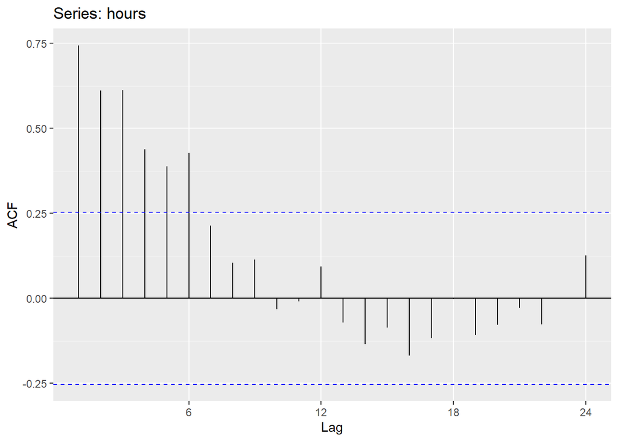

```r
# Plot the correlogram
ggAcf(hours)
```

The correlogram shows large positive correlations at the first few lags that decline gradually, meaning consecutive months are highly related.

# Exercise 3

```r
#install.packages("fma")
library(fma)

#View dataset
labour
```

```
##           Jan      Feb      Mar      Apr      May      Jun      Jul      Aug
## 1978          6468.500 6465.400 6457.600 6436.700 6424.800 6416.600 6403.700
## 1979 6421.200 6508.800 6524.600 6508.200 6475.700 6488.700 6491.000 6456.000
## 1980 6554.600 6655.800 6694.300 6632.800 6690.000 6679.200 6701.700 6675.900
## 1981 6686.800 6784.200 6841.200 6805.800 6791.600 6767.600 6803.600 6774.300
## 1982 6799.400 6921.200 6961.200 6871.600 6894.700 6865.900 6879.300 6840.700
## 1983 6866.700 7014.200 7044.300 6963.800 6993.300 6959.700 6982.200 6927.900
## 1984 6969.300 7101.900 7203.200 7153.200 7125.200 7131.500 7123.600 7070.100
## 1985 7110.100 7269.900 7330.200 7204.100 7267.100 7267.000 7270.300 7248.300
## 1986 7378.500 7527.200 7604.500 7606.500 7573.500 7571.500 7587.600 7516.200
## 1987 7573.200 7722.000 7836.200 7761.600 7738.700 7732.000 7785.700 7694.400
## 1988 7815.600 7892.100 8042.700 8028.200 7947.900 7947.300 7901.800 7892.100
## 1989 8017.300 8167.800 8184.500 8199.400 8247.800 8197.900 8235.100 8197.000
## 1990 8263.000 8402.800 8426.400 8428.500 8466.500 8451.800 8502.300 8412.500
## 1991 8263.000 8436.400 8199.393 8323.465 8606.800 8199.389 8480.800 8425.700
```

[output cut: 23 more lines]

```r
View(labour)

#Transform to tsibble object
labour_tsibble <- as_tsibble(labour)
View(labour_tsibble)
labour_tsibble
```

```
## # A tsibble: 211 x 2 [1M]
##       index value
##       <mth> <dbl>
##  1 1978 Feb 6468.
##  2 1978 Mar 6465.
##  3 1978 Apr 6458.
##  4 1978 May 6437.
##  5 1978 Jun 6425.
##  6 1978 Jul 6417.
##  7 1978 Aug 6404.
##  8 1978 Sep 6412.
##  9 1978 Oct 6416.
## 10 1978 Nov 6407.
## # ℹ 201 more rows
```

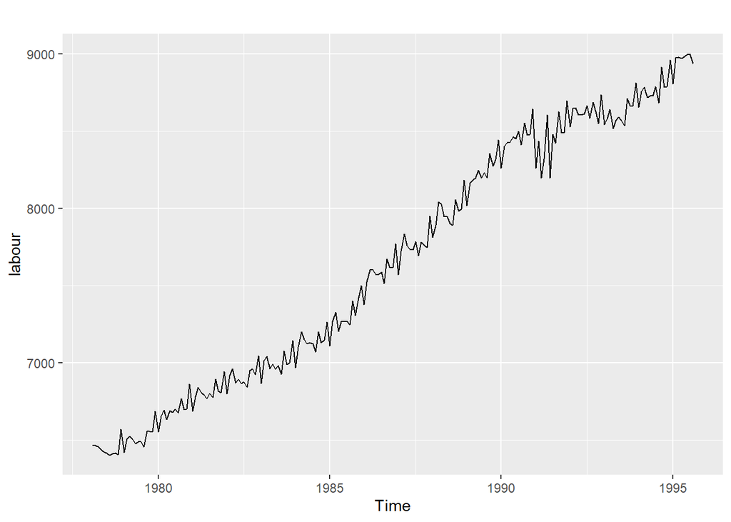

```r
df <- autoplot(labour) # "autoplot" to see the Time Plot
df
```

The time plot shows a strong upward trend in the Australian civilian labour force between 1978 and 1995. The time series increases smoothly over time, indicating non-stationarity in the mean. Short-term oscillations suggest some seasonal variation, but the dominant feature here is the long-run upward trend.

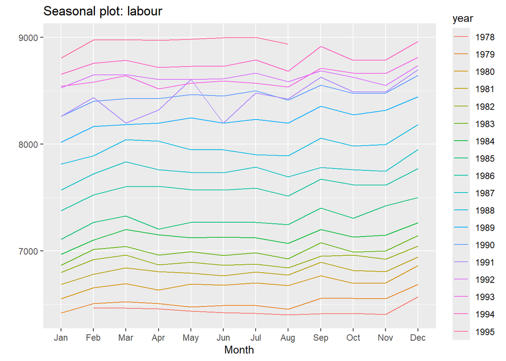

```r
ggseasonplot(labour) # to visualize seasonality
```

The seasonal plot displays monthly patterns over the years. We can notice that, each year, lines shift upward. This suggests that, though the labour force grows each year, the seasonal shape is relatively stable (=simply meaning “consistent seasonality”, a.k.a. months with systematically higher or lower civil labour force). For example, small **peaks** and **dips** repeat across years (see March and September), showing “mild” regular seasonal effects.

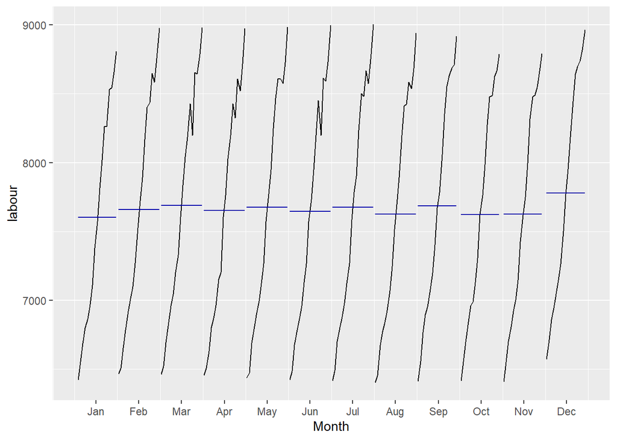

```r
ggsubseriesplot(labour)
```

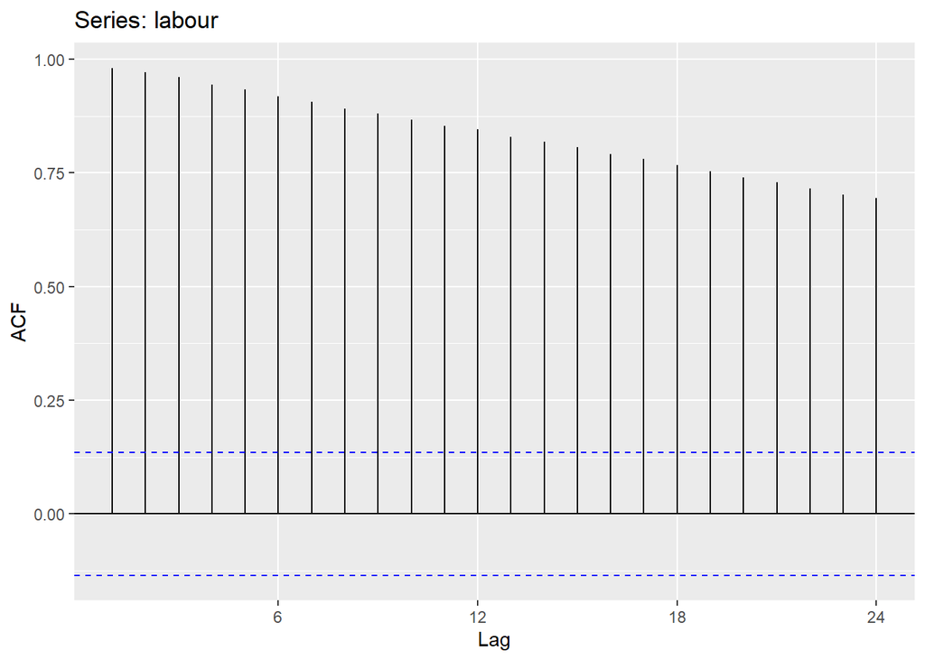

```r
ggAcf(labour)
```

The autocorrelation function (ACF) shows very high positive correlations at short lags that decay slowly, confirming the presence of trend and persistence. There are no strong seasonal spikes, which means that the trend dominates the series’ behavior. Overall, the series is non-stationary due to the slow decay of the ACF.

```r
# Test Box Cox
# Calculate lambda
lambda <- labour_tsibble |>
  features(value, features = guerrero) |>
  pull(lambda_guerrero)
lambda
```

```
## [1] -0.8999268
```

In the initial graph, the labour series shows a clear upward trend from 1978 to 1995. However, the amplitude of fluctuations (= the “height” of ups and downs) appears fairly consistent across the entire range. That means the variance is roughly constant, so a Box–Cox transformation is not strongly needed based on visual inspection. From the plot, the variation/fluctuations remain fairly stable over time. Although the estimated λ = −0.8999 suggests some non-constant variance, the visual evidence indicates that a Box–Cox transformation is not essential.

```r
# Plot the two time series
labour_boxcox <- labour_tsibble %>%
  mutate(lab_ts = box_cox(value, lambda=lambda))
labour_boxcox
```

```
## # A tsibble: 211 x 3 [1M]
##       index value lab_ts
##       <mth> <dbl>  <dbl>
##  1 1978 Feb 6468.   1.11
##  2 1978 Mar 6465.   1.11
##  3 1978 Apr 6458.   1.11
##  4 1978 May 6437.   1.11
##  5 1978 Jun 6425.   1.11
##  6 1978 Jul 6417.   1.11
##  7 1978 Aug 6404.   1.11
##  8 1978 Sep 6412.   1.11
##  9 1978 Oct 6416.   1.11
## 10 1978 Nov 6407.   1.11
## # ℹ 201 more rows
```

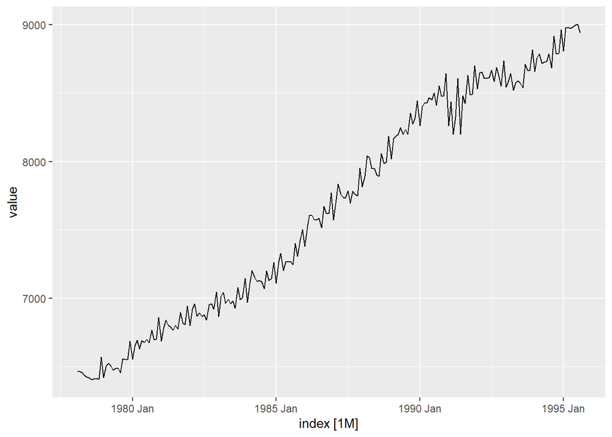

```r
#Plot the Time Plots of the two time series
autoplot(labour_boxcox, value)
```

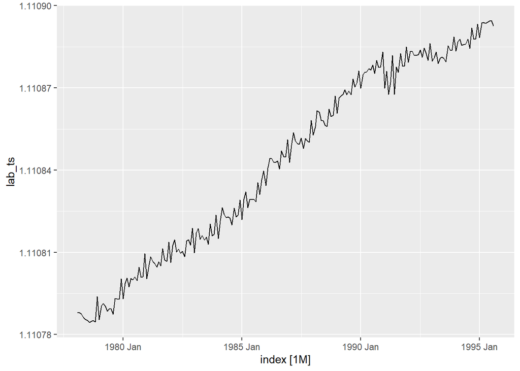

```r
autoplot(labour_boxcox, lab_ts)
```

Or, equivalently, :

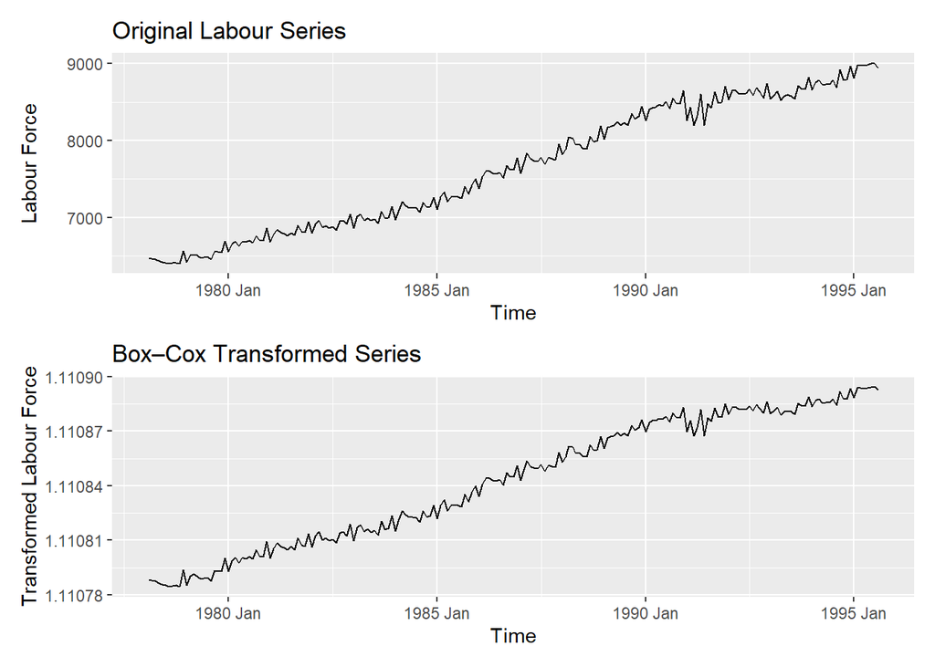

```r
# Original series
p1 <- autoplot(labour_boxcox, value) +
  labs(title = "Original Labour Series", x = "Time", y = "Labour Force")

# Box–Cox transformed series
p2 <- autoplot(mutate(labour_tsibble, lab_ts = box_cox(value, lambda = lambda)), lab_ts) +
  labs(title = "Box–Cox Transformed Series", x = "Time", y = "Transformed Labour Force")

# Display one on top of the other
p1 / p2
```

Or, if you want both time series in the same graph :

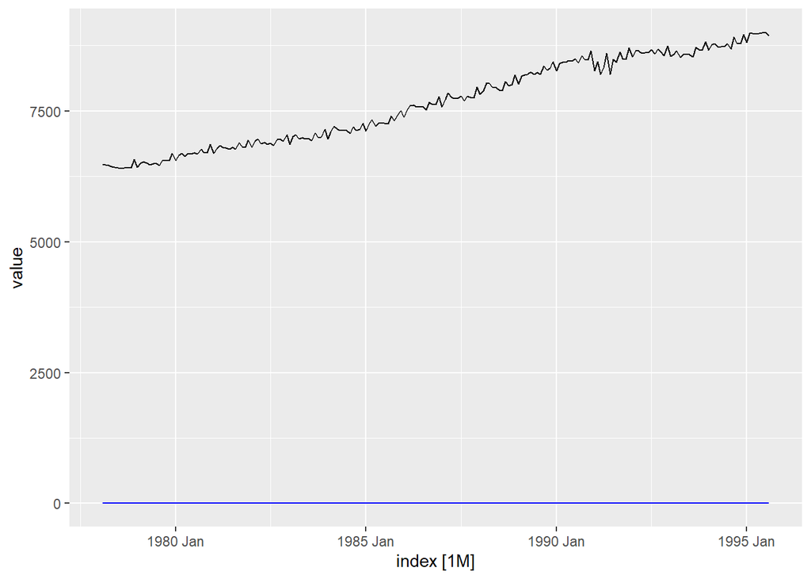

```r
autoplot(labour_boxcox, value) + autolayer(mutate(labour_boxcox, lab_ts = box_cox(value, lambda = lambda)), lab_ts, colour = "blue")
```

After applying the Box–Cox transformation using the Guerrero feature (λ = −0.8999), the transformed series looks very similar to the original one. The overall trend and the size of the fluctuations remain almost unchanged. This confirms my earlier conclusion that the variance in the original series was already quite stable, so the transformation does not have a strong visual effect and is not strictly necessary.